# Behaviors of accounts

#### Amount and balance over time

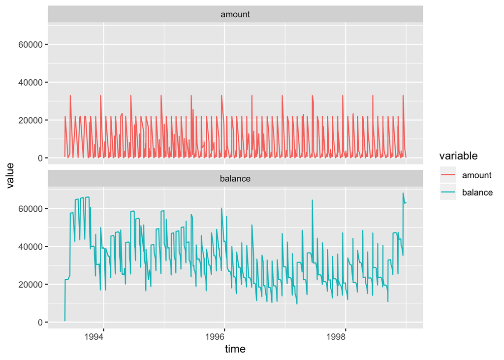

This visualization compares the amount and the balance in the account over time. We see that there is seasonal variation in both graphs. Amount is more stable compared to balance.

#### Credit and debit balance by transaction type

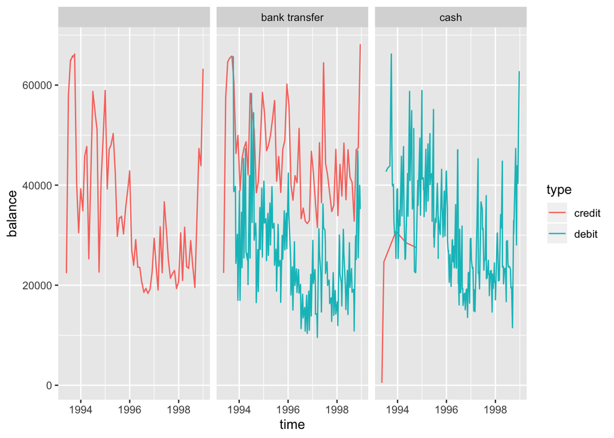

#### Credit and debit amount by transaction type

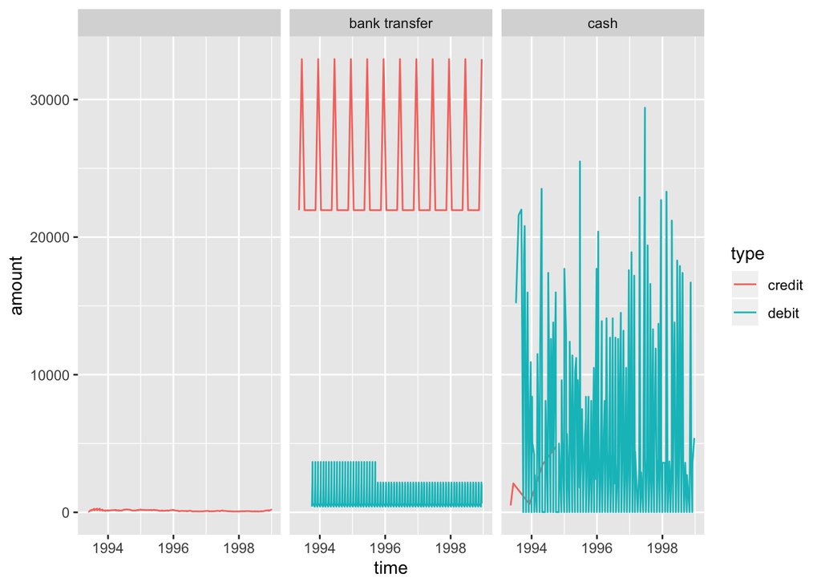

This graph shows the two types of transactions: credit and debit for the three types of transactions over time. We see that this account probably set up auto-payment for credit cards and it is getting seasonal debit transaction that took a down turn in late 1995. Cash transactions are a lot more variational compared to bank transfers. This account is primarily doing cash debit transactions compared to cash credit.